# Multilevel Longitudinal Models

# Overview

We will be using data from the same study (PANDAS) as from last week’s challenge to practice making longitudinal multilevel models. As a reminder, we are not focusing on running models yet. These data include a variable for ID and gender, and then assess self-worth (SPPA_SWORTH), communication quality with mothers (MPACS), and generalized anxiety (SCARED_GAD). Self-worth, communication and GAD were assessed every 6-months at 6 different timepoints. The csv file is the same as the lesson mlm_datacleaning.csv and can be found here: https://columbia-sipps.github.io/workshops/coding_advanced/

Our question for today will be *how did self worth change over time?* We’ll use longitudinal multilevel models in `rstanarm` to approach this

# Load in packages and data

```r
library(tidyverse)
library(rstanarm)
library(bayesplot)
library(tidybayes)

d = read_csv('https://columbia-sipps.github.io/workshop_files/coding-adv-04/mlm-data-cleaning.csv')
```

# Setup

## Filter data for only IDs up to 100 (just for demo purposes of a smaller dataset)

```r
d <- d %>%
  filter(ID <= 100)
```

## Select only the variables we will be plotting

```r
d <- d %>%
  select(ID, contains("SPPA"))
```

## Rename your variables

Rename them so that they are easier to understand

```r
d <- d %>%
# rename vectors
  rename(
    id = 1,
    sworth_1 = 2,
    sworth_2 = 3,
    sworth_3 = 4,
    sworth_4 = 5,
    sworth_5 = 6,
    sworth_6 = 7
    )
```

## Transform our data from wide format to long format

Hint: use the pivot longer function. Note, we want there to be one column for time, and another column for self worth scores. There should be one row of data for each individual’s self worth score at each timepoint (e.g., 6 rows per person if no missing data)

```r
d_long <- d %>%
  tidyr :: pivot_longer(., cols = contains("sworth"), names_to = "time", values_to = "self_worth")
```

## Clean your data in the long format

```r
d_long <- d_long %>%
  dplyr::filter(!is.na(self_worth)) %>%
  dplyr::mutate(time = as.numeric(gsub('sworth_', '', time)))
```

## Plot the data

[output not shown]

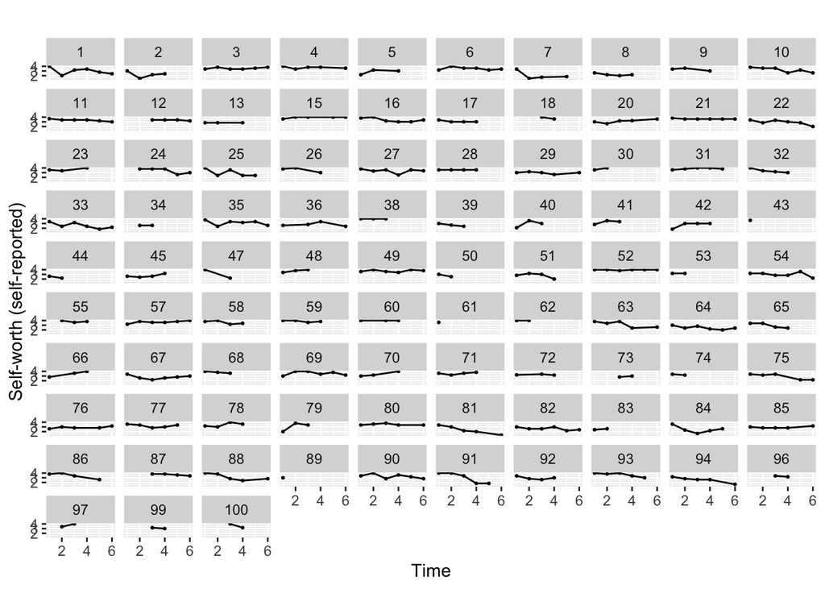

```r
ggplot(data = d_long, aes(x = time, y = self_worth)) +
  geom_line(aes(group = id), color = "black") + geom_point(aes(group = id), size = .4) +
  facet_wrap("id") + # Group variable gives text labels to panels
  labs(x = "Time",
       y = "Self-worth (self-reported)",
       title = "")
```

# 1. Model changes in self worth quality over time with random intercepts only

## Make a random intercept model with rstanarm

`(1|id)` gives us random intercepts - intercepts for each person

```r
m1 = rstanarm::stan_glmer(data = d_long, self_worth ~ time + (1|id), cores = 4)
```

## Interpret the ‘fixed’ effects: what is the average change in self worth over time?

```r
# point estimates
fixef(m1)
```

```
## (Intercept)        time
##  3.46465180 -0.08943226
```

```r
# summary of full model
m1_summary = summary(m1, probs = c(.025, .975))
m1_summary[1:10, ]
```

```
##                            mean         mcse         sd         2.5%
## (Intercept)          3.46388003 0.0014967630 0.06467047  3.338117858
## time                -0.08942295 0.0002135406 0.01524420 -0.119868637
## b[(Intercept) id:1] -0.16016513 0.0025823953 0.16985973 -0.492089150
## b[(Intercept) id:2] -0.76832437 0.0028386596 0.20350379 -1.165416272
## b[(Intercept) id:3]  0.34686894 0.0026190080 0.17195948  0.009442167
## b[(Intercept) id:4]  0.43773540 0.0028000295 0.18139829  0.086202225
## b[(Intercept) id:5] -0.32916274 0.0031829013 0.22428210 -0.773475638
## b[(Intercept) id:6]  0.29266237 0.0025694379 0.17440615 -0.043970021
## b[(Intercept) id:7] -0.89665622 0.0028051782 0.20525850 -1.292143626
## b[(Intercept) id:8] -0.76718368 0.0029469372 0.19643870 -1.148060354
##                           97.5% n_eff      Rhat
## (Intercept)          3.58842888  1867 1.0003305
## time                -0.05893875  5096 0.9994887
## b[(Intercept) id:1]  0.17402994  4326 0.9998193
## b[(Intercept) id:2] -0.36703143  5139 0.9995735
## b[(Intercept) id:3]  0.69155946  4311 0.9994173
## b[(Intercept) id:4]  0.79989640  4197 1.0001505
## b[(Intercept) id:5]  0.10494675  4965 1.0000878
## b[(Intercept) id:6]  0.62290630  4607 1.0002792
## b[(Intercept) id:7] -0.49704225  5354 0.9992195
## b[(Intercept) id:8] -0.36809148  4443 0.9998679
```

> - Woah! Why so much output here? Well, all of the `b[(Intercept) id:1]` parameters in the model are the intercepts for each different person (each id), so there are a lot of parameterss in this model!

## Plot the model predictions for the group average self worth quality (fixed effect) over time

Note that we have to add the `re_formula = NA` argument in the `add_fitted_draws()` function here to tell the model we want just the fixed effects (not predictions for specific participants)

```r
# define a data frame of timepoints to make predictions for for the group average
pred_frame = data.frame(time = 1:6)

# get predictions using tidybayes!
# again this dataframe looks a little confuisng at first, but the outcome (self worth) is always in the .value column
fixed_preds_m1 = tidybayes::add_fitted_draws(m1, newdata = pred_frame, re_formula = NA)
```

## Make a plot of predicted self worth over time

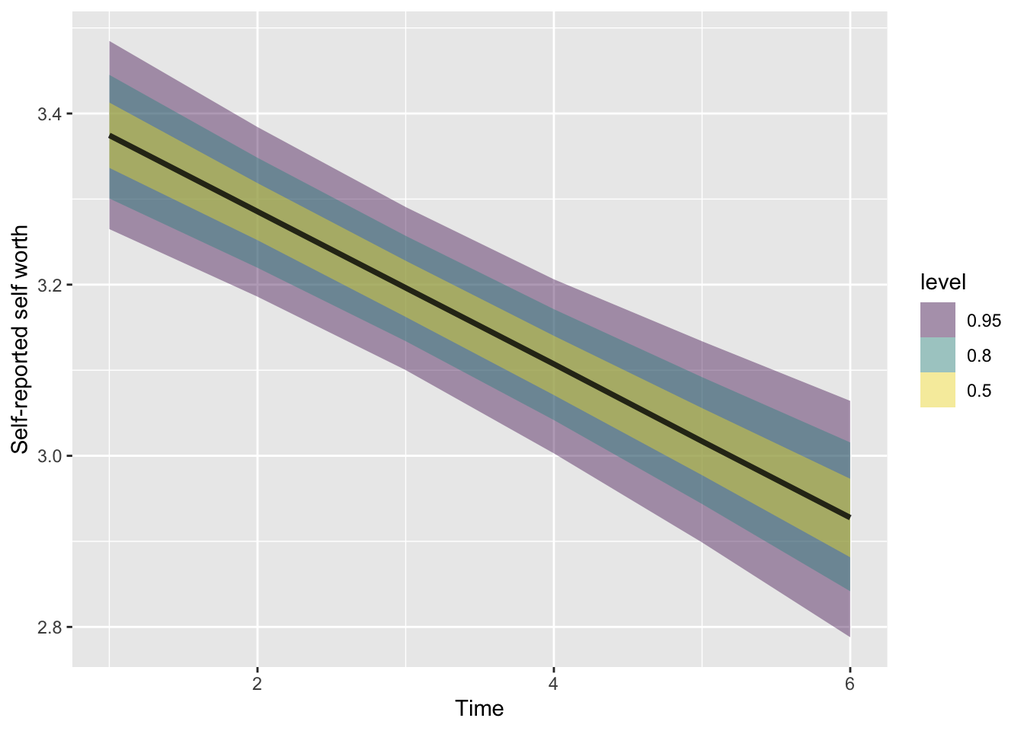

```r
ggplot(fixed_preds_m1, aes(x = time, y= .value)) +
  tidybayes::stat_lineribbon(alpha = .4) +
  labs(x = 'Time', y = 'Self-reported self worth')
```

a little nicer looking…

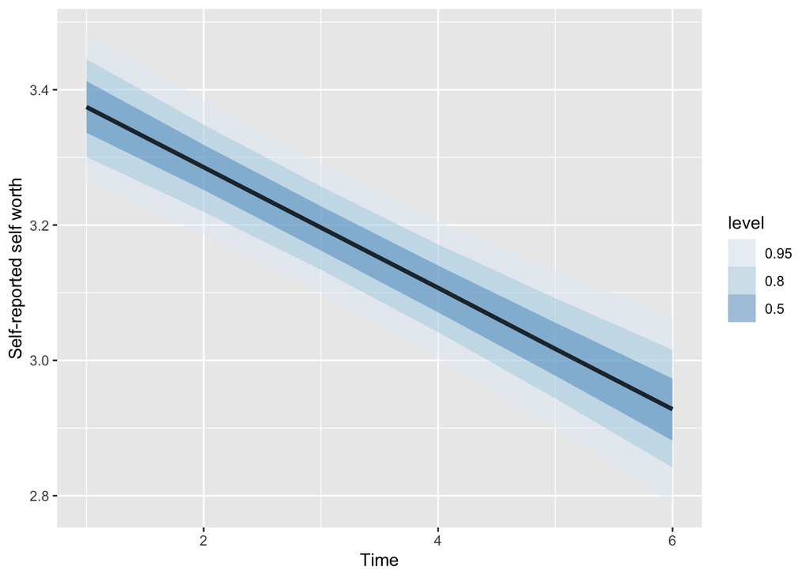

```r
ggplot(fixed_preds_m1, aes(x = time, y= .value)) +
  tidybayes::stat_lineribbon(alpha = .4) +
  labs(x = 'Time', y = 'Self-reported self worth') +
  scale_fill_brewer()
```

We can get predictions for each point in the original dataset by specificying the original dataset `d_long` as `newdata`

We also use the `median_qi` function to summarize and get the median and a posterior interval for each prediction. Now the `.value` column will be the median model prediction for each datapoint. We won’t use `.upper` and `.lower` yet but we could later

```r
participant_preds_m1 = tidybayes::add_fitted_draws(model = m1, newdata = d_long) %>%
  median_qi(.value, .width = .95)
```

Now, add participant ‘spaghetti’ to our plot. We can see all the lines are parallel – they have different intercepts (random intercepts!) but the same exact slope as the fixed effect. This is because there are no random slopes – slopes cannot vary for different participants under this model.

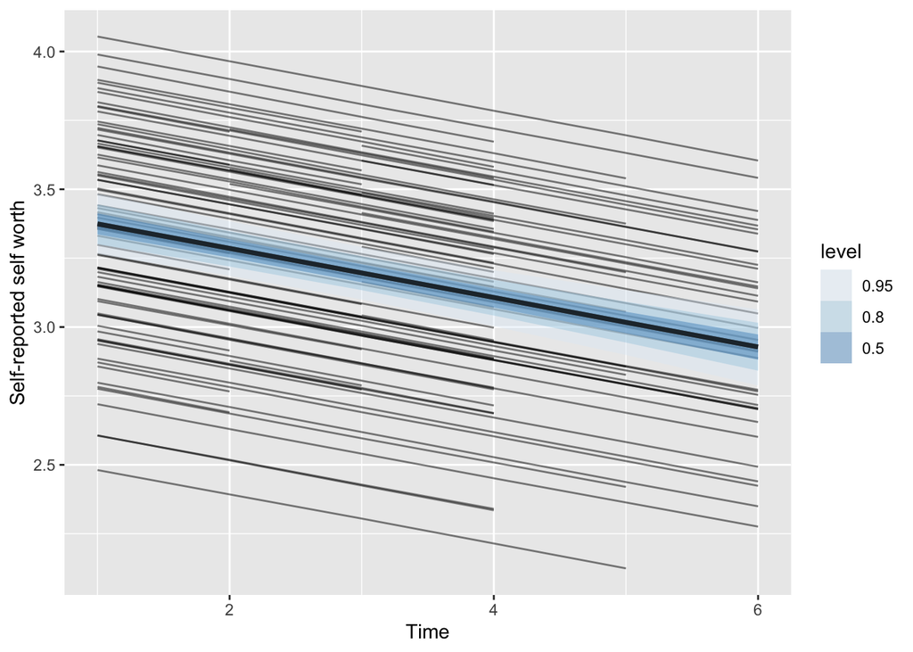

```r
ggplot(fixed_preds_m1, aes(x = time, y= .value)) +
  geom_line(data = participant_preds_m1, aes(group = id), alpha = .5) +
  tidybayes::stat_lineribbon(alpha = .4) +
  labs(x = 'Time', y = 'Self-reported self worth') +
  scale_fill_brewer()
```

# 2. Model changes in self worth quality over time with random intercepts AND random slopes

## Make a random slope + intercept model with rstanarm

```r
m2 = rstanarm::stan_glmer(data = d_long, self_worth ~ time + (time|id), cores = 4)
```

## Interpret the ‘fixed’ effects: what is the average change in self worth over time?

```r
# point estimates
fixef(m1)
```

```
## (Intercept)        time
##  3.46465180 -0.08943226
```

```r
# summary of full model (a good way to shorten output)
g = summary(m2, probs = c(.025, .975))
g[1:5,]
```

```
##                            mean         mcse         sd       2.5%       97.5%
## (Intercept)          3.45436219 0.0009549072 0.06268023  3.3325389  3.57788559
## time                -0.08559143 0.0004424263 0.02061516 -0.1252687 -0.04494921
## b[(Intercept) id:1] -0.01269774 0.0030898036 0.23607912 -0.4845167  0.45622626
## b[time id:1]        -0.04951025 0.0009222081 0.06387882 -0.1822634  0.07523683
## b[(Intercept) id:2] -0.56752480 0.0047533576 0.27912209 -1.1455183 -0.05639859
##                     n_eff      Rhat
## (Intercept)          4309 1.0011004
## time                 2171 1.0029477
## b[(Intercept) id:1]  5838 0.9992595
## b[time id:1]         4798 0.9995458
## b[(Intercept) id:2]  3448 0.9996078
```

Now, we have parameters like `b[time id:2]` for each participant! These are the random slopes!

## Plot the model predictions for the group average self worth quality (fixed effect) over time

Just like with the previous model

```r
fixed_preds_m2 = tidybayes::add_fitted_draws(m2, newdata = pred_frame, re_formula = NA)
```

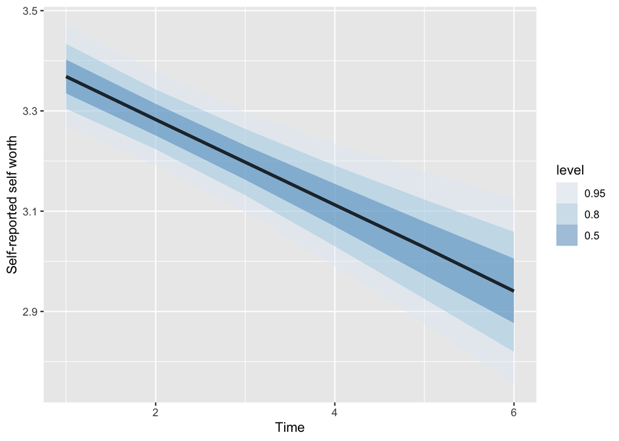

```r
ggplot(fixed_preds_m2, aes(x = time, y= .value)) +
  tidybayes::stat_lineribbon(alpha = .4) +
  labs(x = 'Time', y = 'Self-reported self worth') +
  scale_fill_brewer()
```

## Now, add ‘spaghetti plot’ lines for each participant’s predicted self worth quality over time to your plot

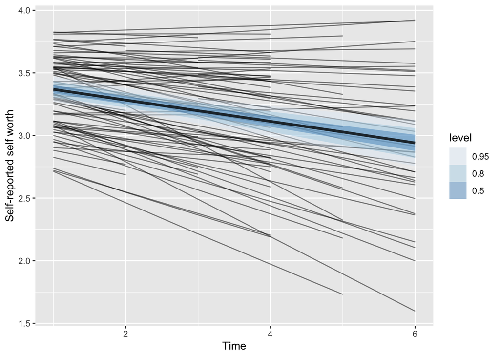

```r
participant_preds_m2 = tidybayes::add_fitted_draws(model = m2, newdata = d_long) %>%
  median_qi(.value, .width = .95)

ggplot(fixed_preds_m2, aes(x = time, y= .value)) +
  geom_line(data = participant_preds_m2, aes(group = id), alpha = .5) +
  tidybayes::stat_lineribbon(alpha = .4) +
  labs(x = 'Time', y = 'Self-reported self worth') +
  scale_fill_brewer()
```

> - Now, we can see the lines for the model predictions for different participants are not parallel! Random intercepts AND random slopes

## Create indiviudal panel plots to check our model fits

> - Now, we might want to make a panel plot to see how well our model fits each participant, comparing the model predicitons with the raw data
> - First we plot the raw data
> - Then we add in our predictions from m2 & m1

```r
panel_plt = ggplot(data = d_long, aes(x = time, y = self_worth)) +
  geom_line(aes(group = id, color = "Raw Daata")) + geom_point(aes(group = id), size = .4) +
  geom_line(data = participant_preds_m1 , aes(x = time, y = .value, color = 'Random Intercept Model Prediction')) +
  geom_line(data = participant_preds_m2, aes(x = time, y = .value, color = 'Random Slope Model Prediction')) +
  facet_wrap("id") + # Group variable gives text labels to panels
  labs(x = "Time",
       y = "Self-reported self worth",
       title = "")


# save to a file since it's a little hard to see inline
ggsave(panel_plt, file = 'panel_plt.png', height = 8, width = 15)
```